# Figures

154.9

1,555

8,857

NA

NA

148.6

±

79.9

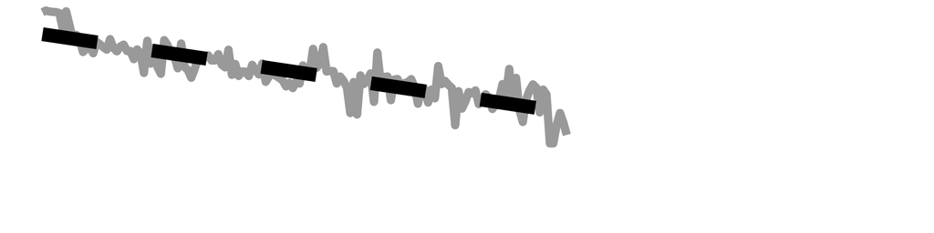

8.3

±

1.3

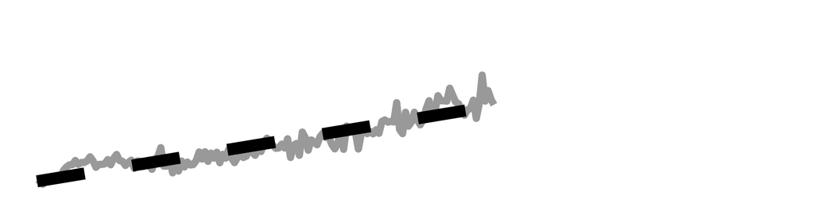

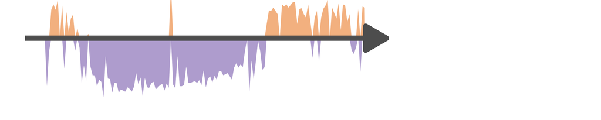

140073

174.3

1,692

7,094

102

134

190.5

±

117.2

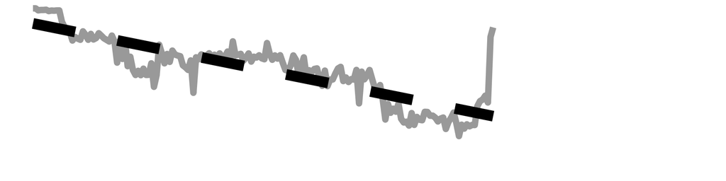

10.3

±

2.0

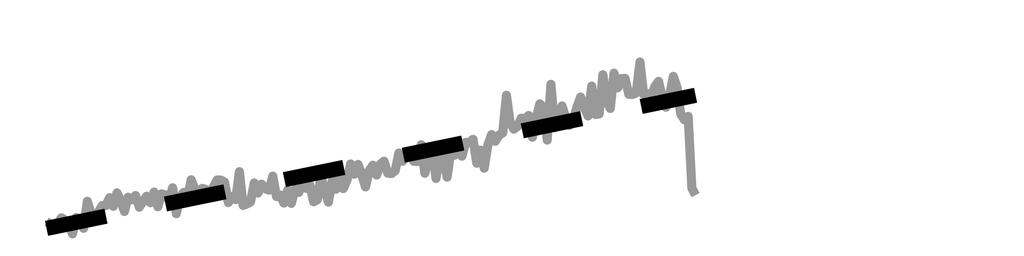

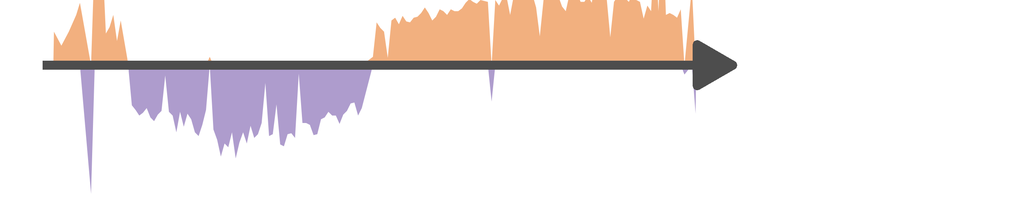

140075

142.3

1,451

6,608

NA

NA

132.5

±

90.3

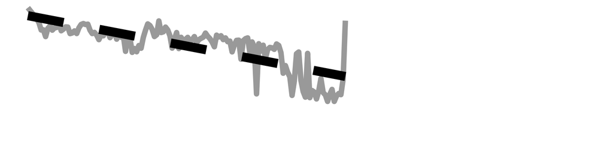

7.8

±

1.5

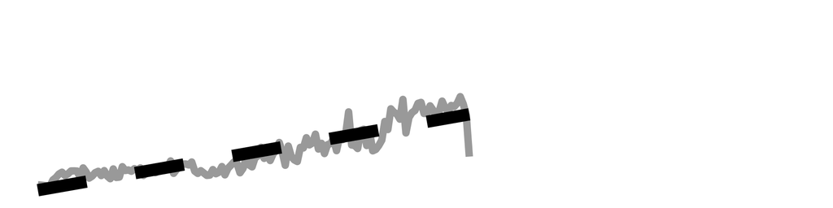

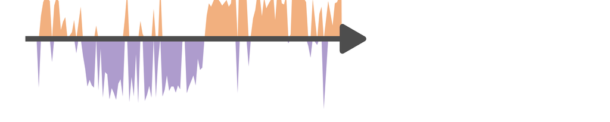

```r
# # for export
# summary_table_es %>% gtsave_extra(
#   "test_table_1.png",
#   vwidth = 2000,
#   vheight = 580,
#   # cliprect = "viewport"
# )
```

Title: Descriptive statistics and visual representations of the dataset’s first offshore foraging trip for each northern and southern elephant seal. For maximum depth (m; note the inverted y-axis) and dive duration (min), the trend represents the changes in the daily 95th percentile through time (solid gray line) associated with a linear regression (black dashes). For drift rate (m.s-1), the daily median was calculated to represent the evolution over time, with positive values in orange and negative in violet. The measurements of length and mass were made at weaning.

### Extra

```r
# by species
data_comp %>%
  .[!is.na(lat), `:=`(
    sunrise_today = maptools::sunriset(matrix(c(lon, lat), ncol = 2),
      date,
      direction = "sunrise",
      POSIXct.out = TRUE
    )$time,
    sunset_today = maptools::sunriset(matrix(c(lon, lat), ncol = 2),
      date,
      direction = "sunset",
      POSIXct.out = TRUE
    )$time
  ), ] %>%
  # calculation day-time length
  .[, day_time := as.numeric(difftime(sunset_today,
    sunrise_today,
    units = "hours"
  ))] %>%
  # calculation night-time length
  .[, night_time := 24 - day_time] %>%
  # calculate maxdepth and dduration
  .[, .(
    result_depth = paste(
      round(mean(maxdepth), 1),
      "±",
      round(sd(maxdepth), 1)
    ),
    result_duration = paste(
      round(mean(dduration / 60), 1),
      "±",
      round(sd(dduration / 60), 1)
    ),
    result_day_time = paste(
      round(mean(day_time, na.rm = T), 1),
      "±",
      round(sd(day_time, na.rm = T), 1)
    ),
    result_night_time = paste(
      round(mean(night_time, na.rm = T), 1),
      "±",
      round(sd(night_time, na.rm = T), 1)
    )
  ), by = .(sp_rename)] %>%
  # add wean mass based on Weanling Dive Metada.xlsx
  merge(., data.table(
    id_rename = c(
      "2018070",
      "2018072",
      "2018074",
      "2018080",
      "140059",
      "140060",
      "140062",
      "140063",
      "140068",
      "140069",
      "140072",
      "140073",
      "140075"
    ),
    sp_rename = c(
      rep("Northern elephant seal", 4),
      rep("Southern elephant seal", 9)
    ),
    weanmass = c(132, 138, 119, 142, 118, 112, 85, NA, 125, NA, NA, 102, NA)
  ) %>%
    .[, .(result_mass = paste(
      round(mean(weanmass, na.rm = T), 1),
      "±",
      round(sd(weanmass, na.rm = T), 1)
    )),
    by = sp_rename
    ],
  by = "sp_rename"
  ) %>%
  merge(., data.table(
    id_rename = c(
      "2018070",
      "2018072",
      "2018074",
      "2018080",
      "140059",
      "140060",
      "140062",
      "140063",
      "140068",
      "140069",
      "140072",
      "140073",
      "140075"
    ),
    sp_rename = c(
      rep("Northern elephant seal", 4),
      rep("Southern elephant seal", 9)
    ),
    lenmass = c(144, NA, 131, 142, 141, 141, 118, NA, 136, NA, NA, 134, NA)
  ) %>%
    .[, .(result_len = paste(
      round(mean(lenmass, na.rm = T), 1),
      "±",
      round(sd(lenmass, na.rm = T), 1)
    )),
    by = sp_rename
    ],
  by = "sp_rename"
  ) %>%
  merge(., data_comp[, .(travel_distance = sum(travel_distance, na.rm = T) / 1000),
    by = .(.id, sp_rename)
  ] %>%
    .[, travel_distance := na_if(travel_distance, 0)] %>%
    .[, .(result_distance = paste(round(mean(
      travel_distance,
      na.rm = T
    ), 1), "±", round(sd(
      travel_distance,
      na.rm = T
    ), 1))), by = .(sp_rename)], by = "sp_rename") %>%
  merge(., data_comp[, .(nb_days = as.numeric(difftime(max(date),
    min(date),
    units = "day"
  ))),
  by = .(.id, sp_rename)
  ] %>%
    .[, .(nb_days = paste(
      round(mean(nb_days, na.rm = T), 1),
      "±",
      round(sd(nb_days, na.rm = T), 1)
    )),
    by = .(sp_rename)
    ], by = "sp_rename") %>%
  gt() %>%
  tab_spanner(
    label = md("Dive"),
    columns = c("result_depth", "result_duration")
  ) %>%
  tab_spanner(
    label = md("Length (days)"),
    columns = c("result_day_time", "result_night_time")
  ) %>%
  tab_spanner(
    label = md("Weaning"),
    columns = c("result_mass", "result_len")
  ) %>%
  tab_spanner(
    label = md("Travel"),
    columns = c("result_distance")
  ) %>%
  cols_label(
    sp_rename = "Species",
    result_depth = "Depth (m)",
    result_duration = "Duration (days)",
    result_day_time = "Day",
    result_night_time = "Night",
    result_mass = "Mass (kg)",
    result_len = "Length (cm)",
    result_distance = "Distance (km)"
  ) %>%
  opt_row_striping() %>%
  # settings
  tab_options(
    # # width table
    table.width = pct(175),
    # table.width = pct(150),
    # padding = vertical space between rows
    data_row.padding = px(3),
    # horizontal scroll
    container.overflow.x = T
  )
```

[output not shown]